# 2023_Deep_7_catch_exploration

# Ehu

Catch through time

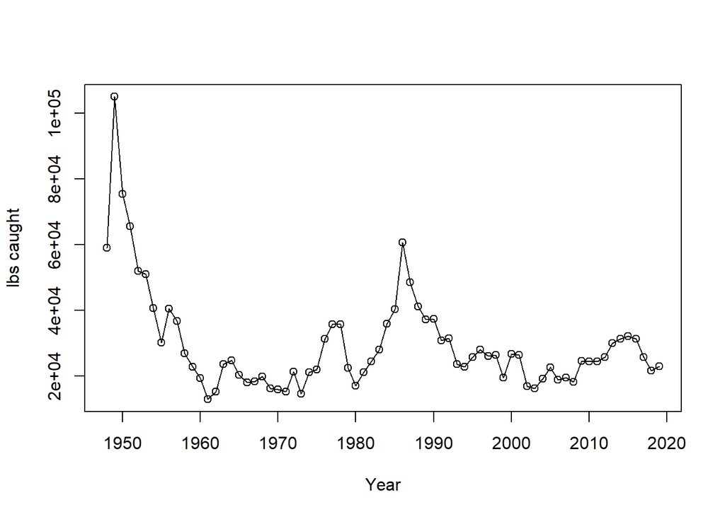

Number of catch records by year

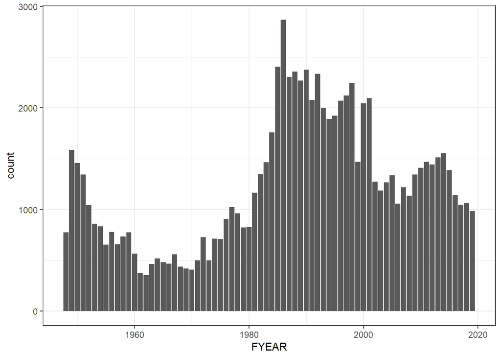

```
##    Min. 1st Qu.  Median    Mean 3rd Qu.    Max.
##    1948    1978    1991    1988    2002    2019
```

Catch by calendar month (monthly mean among calendar years)

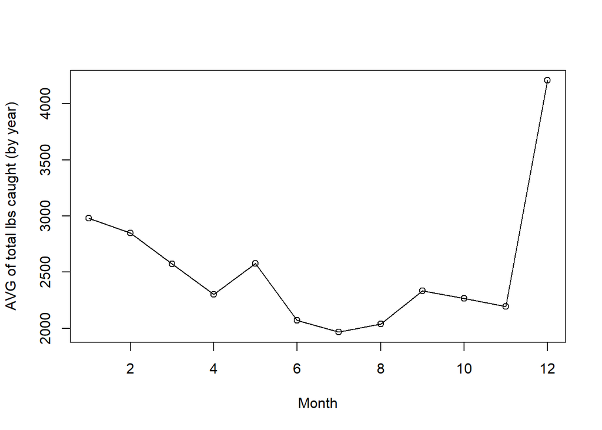

Number of catch records by region (years pooled)

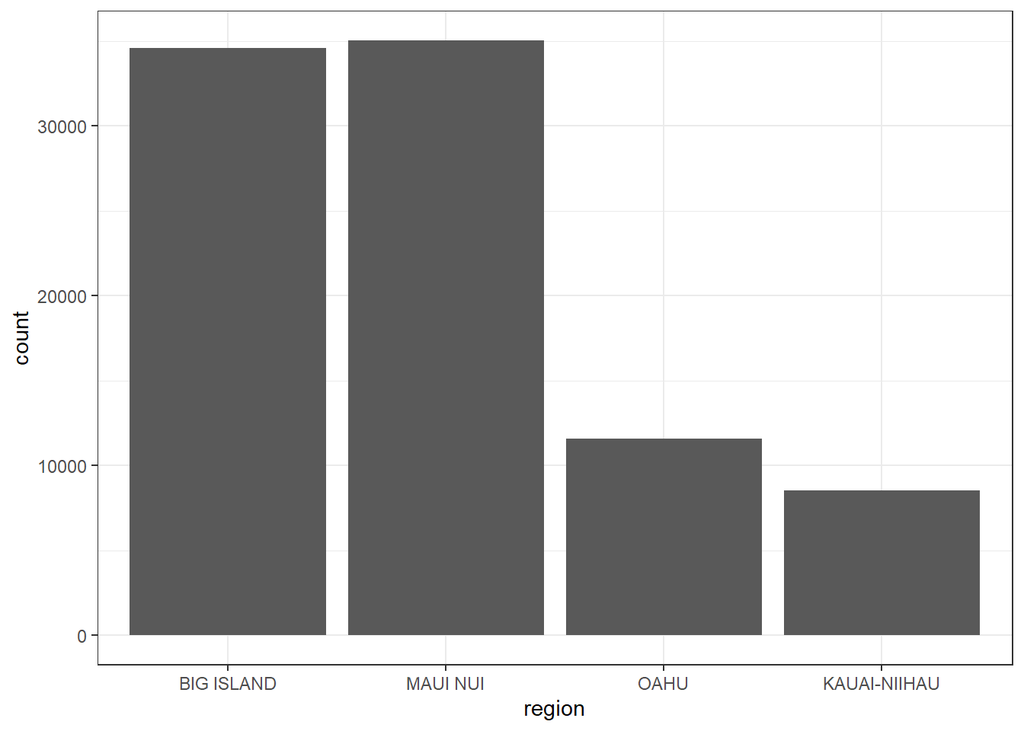

```
##   BIG ISLAND     MAUI NUI         OAHU KAUAI-NIIHAU
##        34587        35021        11585         8525
```

Proportion of ehu catch (in lbs) by island region through time

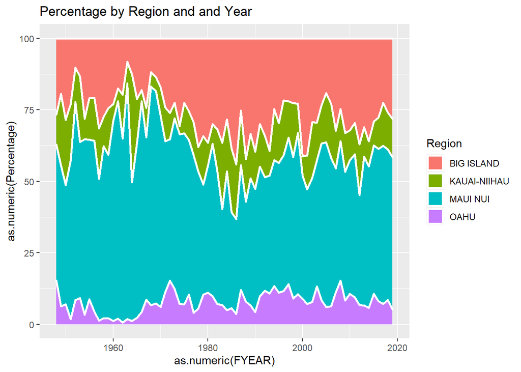

Look at catch by HDAR reporting area

Proportion of records in top 10 and 20 areas, respectively (years pooled).

```
## [1] 0.5310299
```

```
## [1] 0.7145768
```

Top 10 areas ("Group.1")

```
##    Group.1         x
## 64     331 269790.02
## 63     328 262463.84
## 55     320 108072.80
## 60     325  88809.10
## 6      105  81758.90
## 56     321  79285.16
## 15     125  74550.60
## 16     126  71809.40
## 62     327  49846.30
## 7      106  47839.50
```

Maps of catch by HDAR reporting area (total and decade)

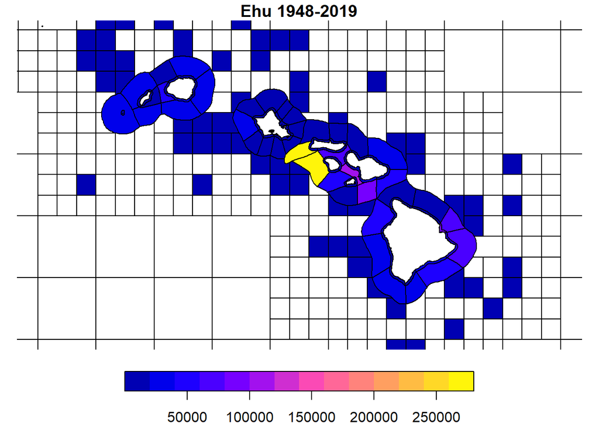

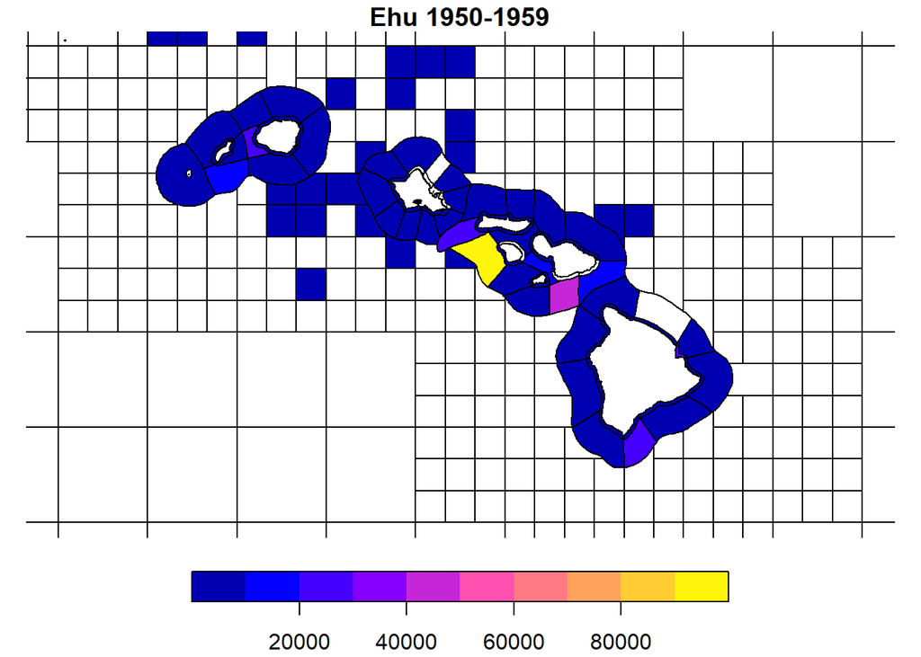

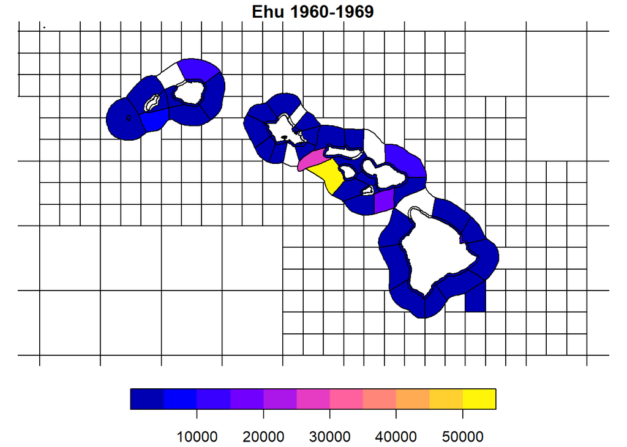

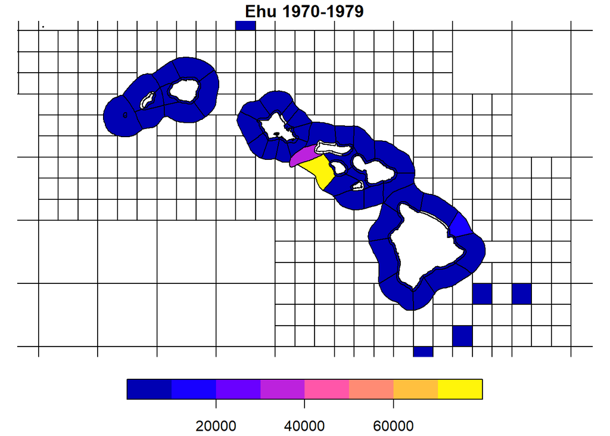

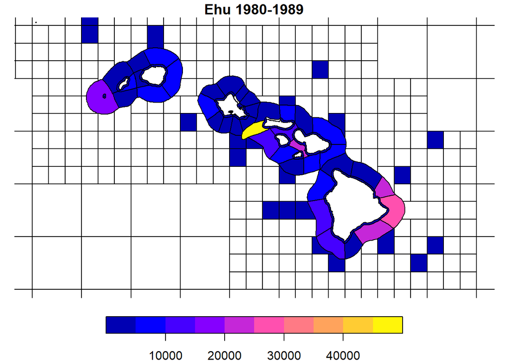

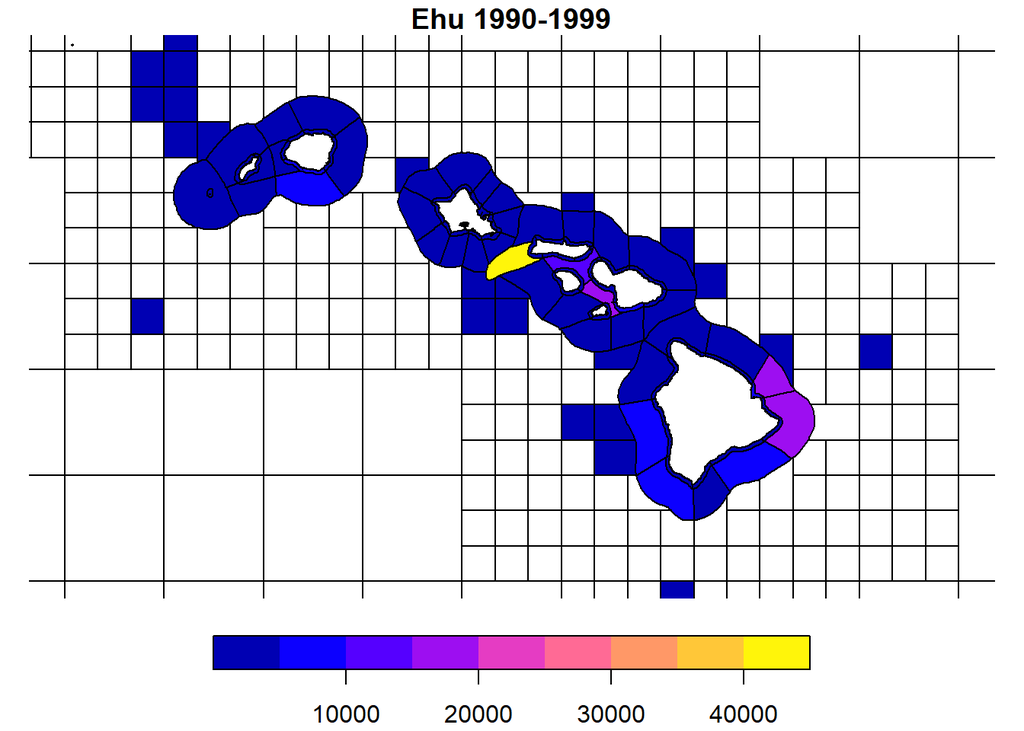

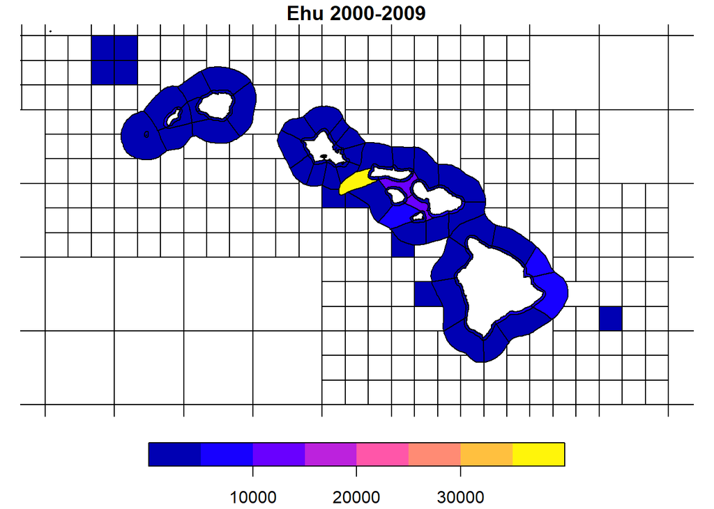

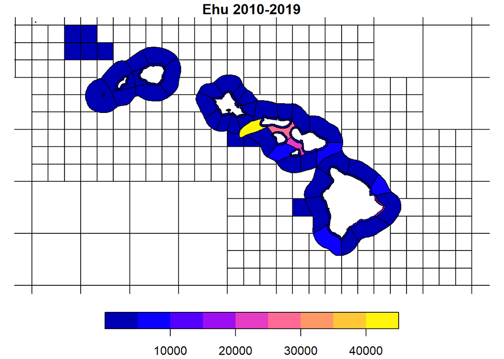

Catch by gear

Proportion of catch (lbs) and records, respectively, on deep-sea handline

```
## [1] 0.9543067
```

```
## [1] 0.9519271
```

Catch by gear through time

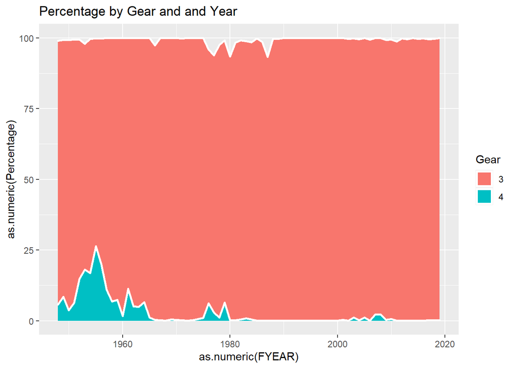

# Hapu

Catch through time

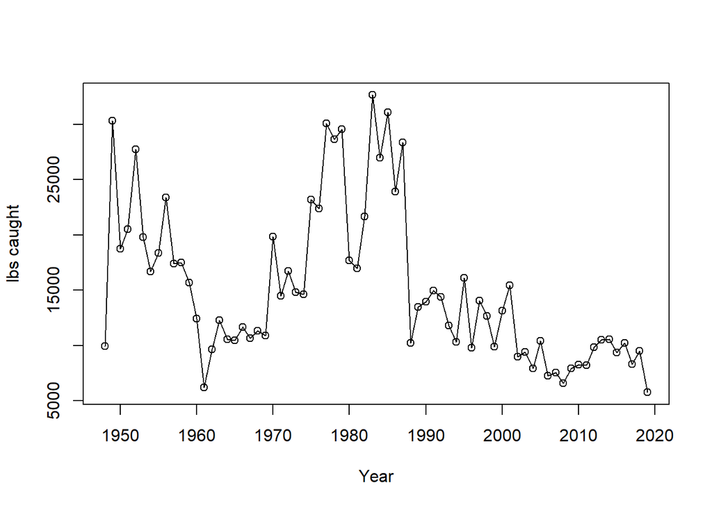

Number of catch records by year

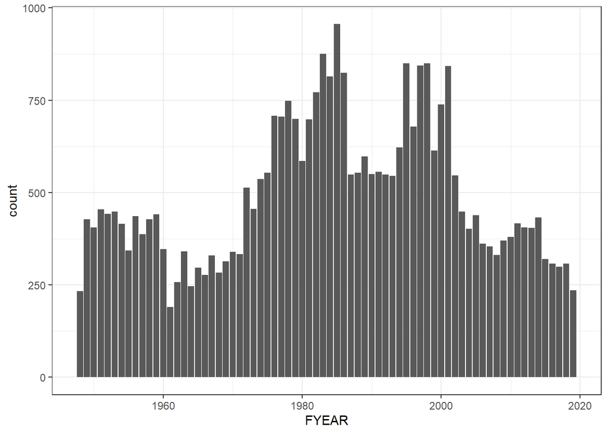

```
##    Min. 1st Qu.  Median    Mean 3rd Qu.    Max.
##    1948    1972    1985    1985    1999    2019
```

Catch by calendar month (monthly mean among calendar years)

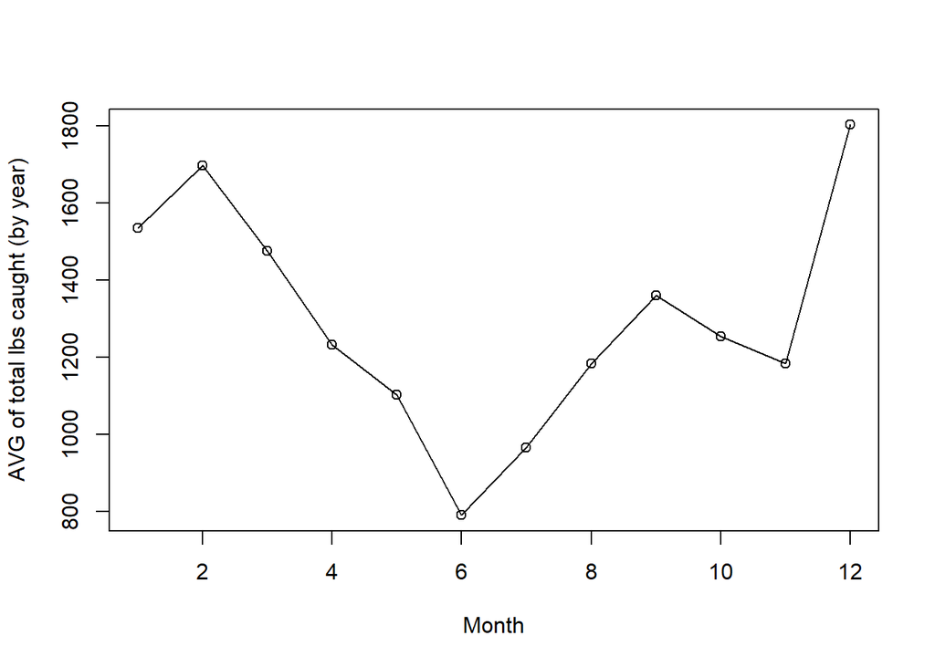

Number of catch records by region (years pooled)

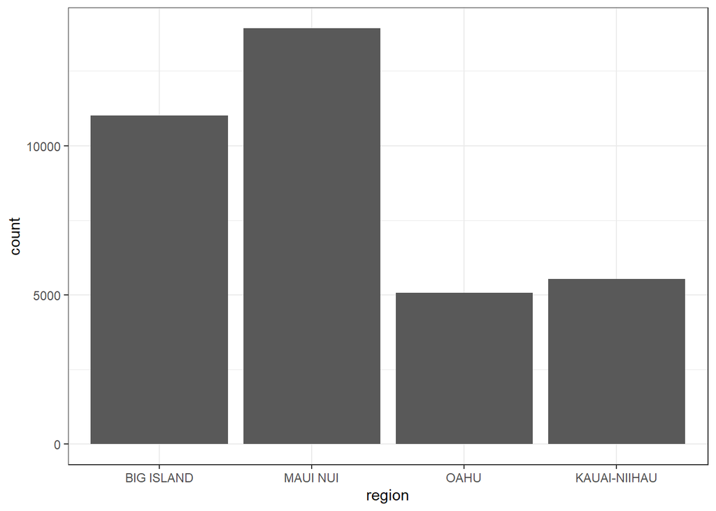

```
##   BIG ISLAND     MAUI NUI         OAHU KAUAI-NIIHAU
##        11018        13931         5065         5543
```

Proportion of hapu catch (in lbs) by island region through time

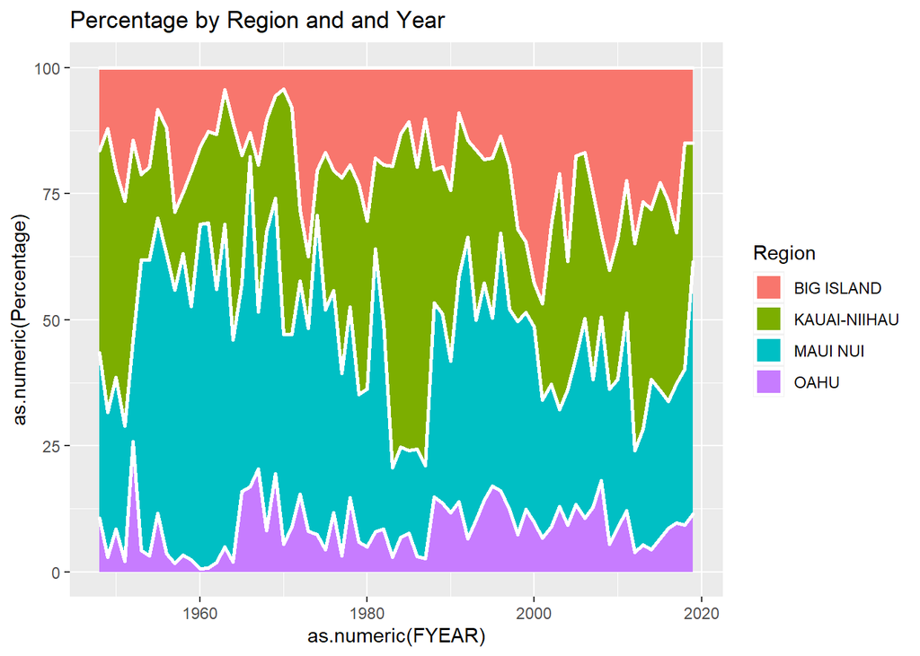

Look at catch by HDAR reporting area

Proportion of records in top 10 and 20 areas, respectively (years pooled).

```
## [1] 0.4490745
```

```
## [1] 0.6258097
```

Top 10 areas ("Group.1")

```
##     Group.1        x
## 64      331 79733.91
## 125     528 74547.43
## 63      328 72076.10
## 55      320 58203.80
## 124     527 41392.50
## 60      325 37180.20
## 139     593 36313.74
## 120     523 31901.60
## 62      327 31412.01
## 12      122 28105.40
```

Maps of catch by HDAR reporting area (total and decade)

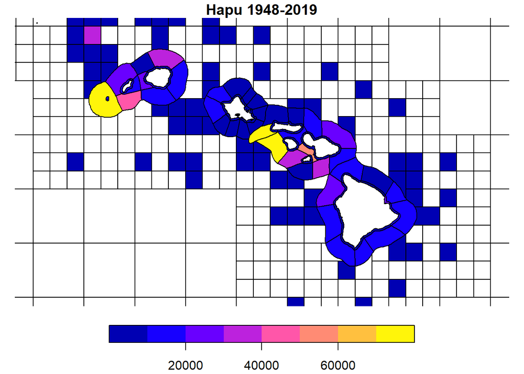

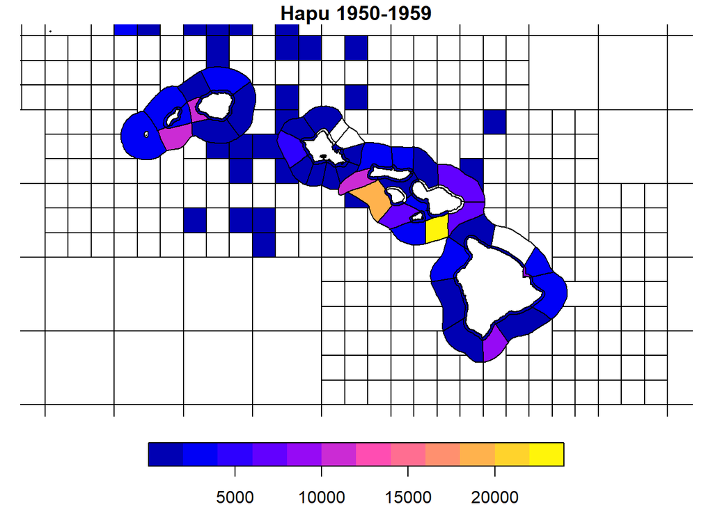

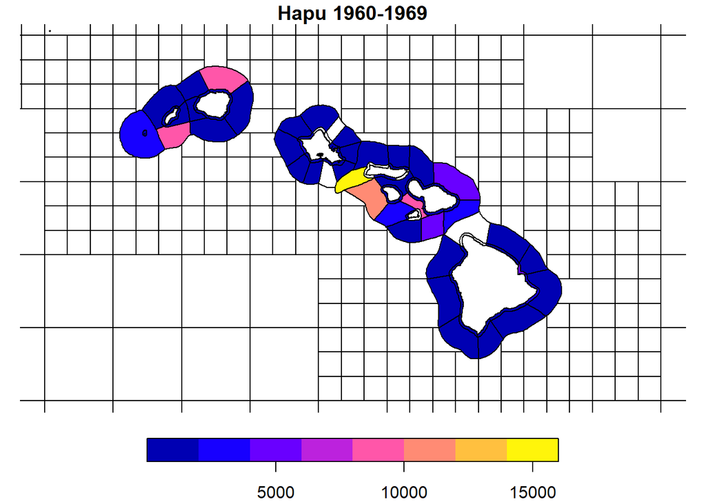

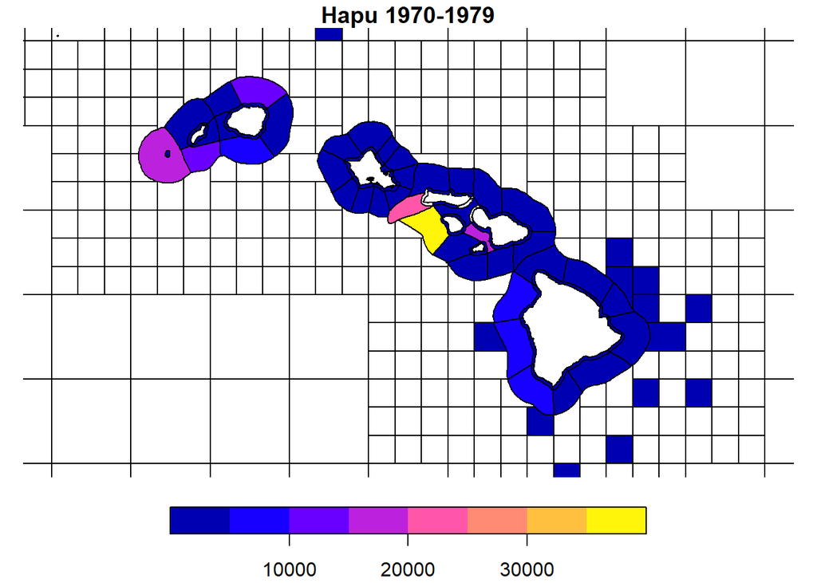

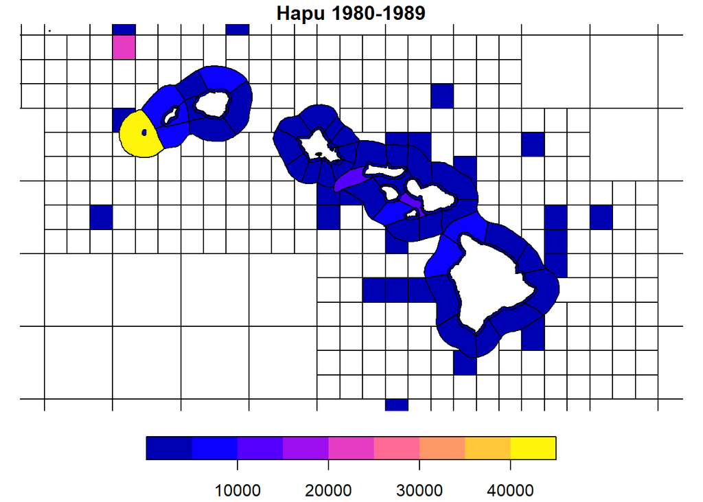

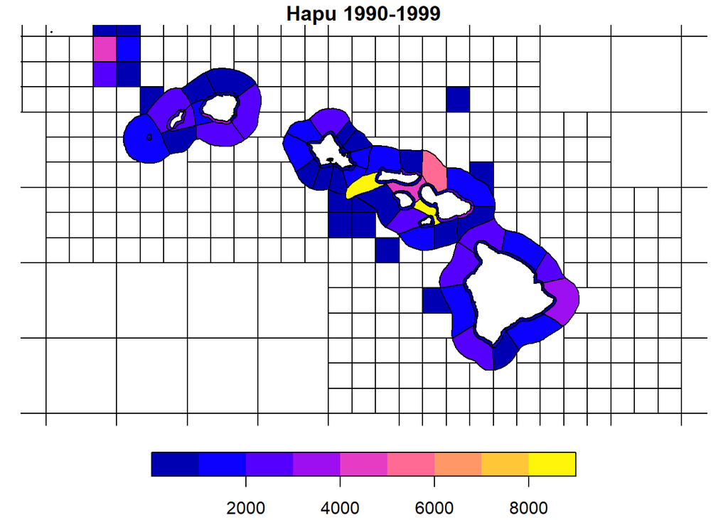

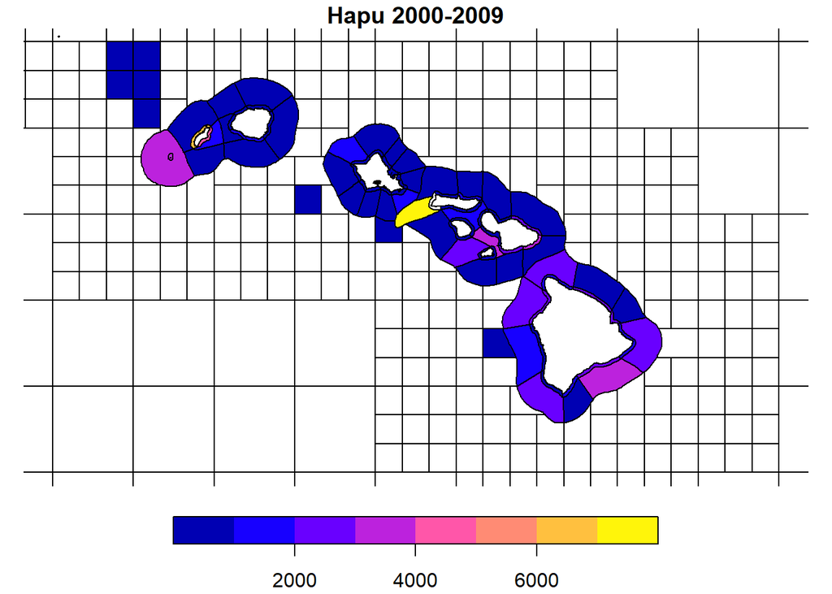

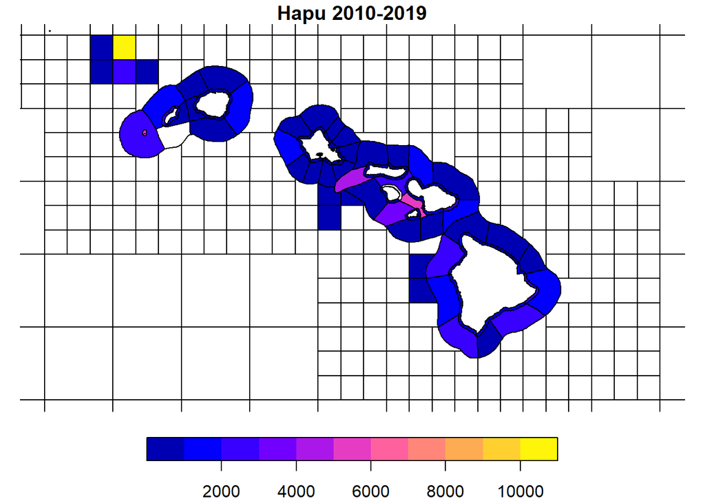

Catch by gear

Proportion of catch (lbs) and records, respectively, on deep-sea handline

[output not shown]

[output not shown]

Catch by gear through time

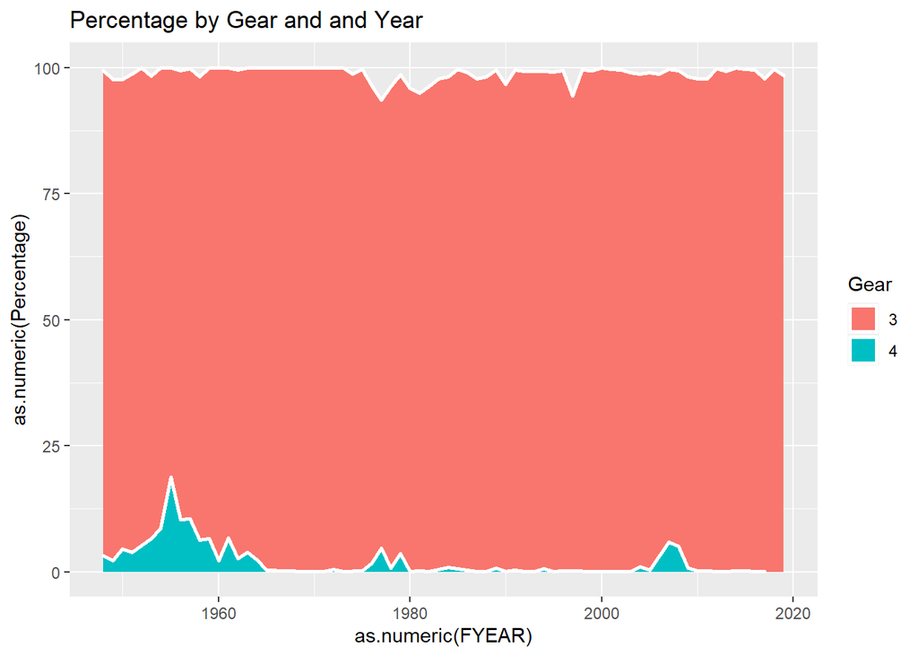

# Kalekale

Catch through time

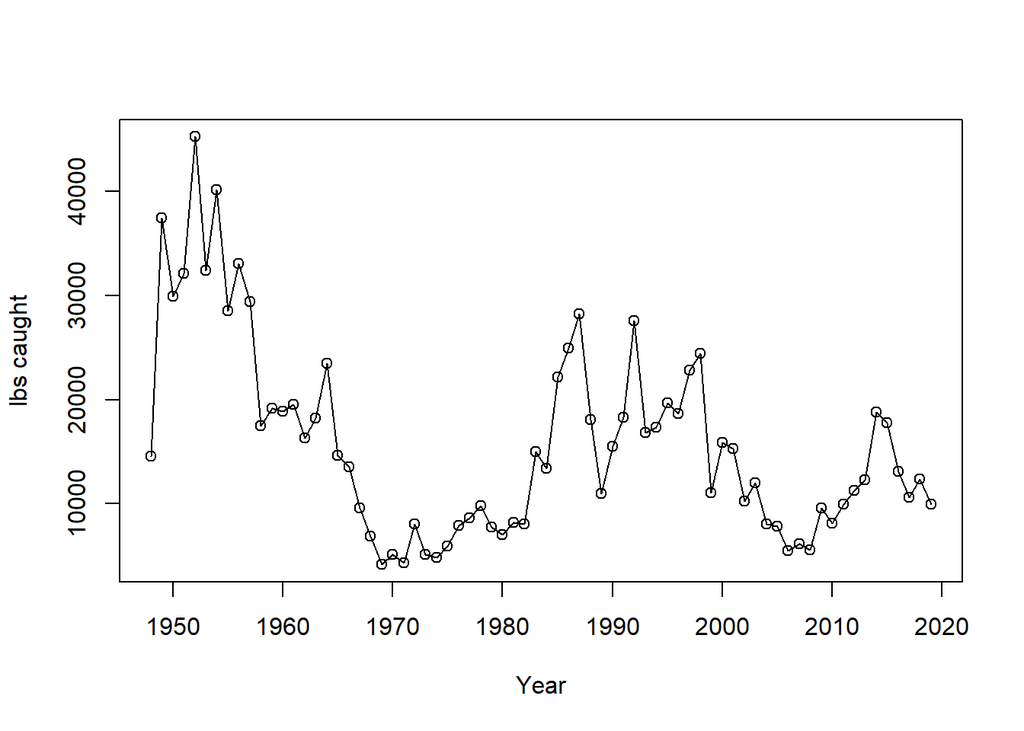

Number of catch records by year

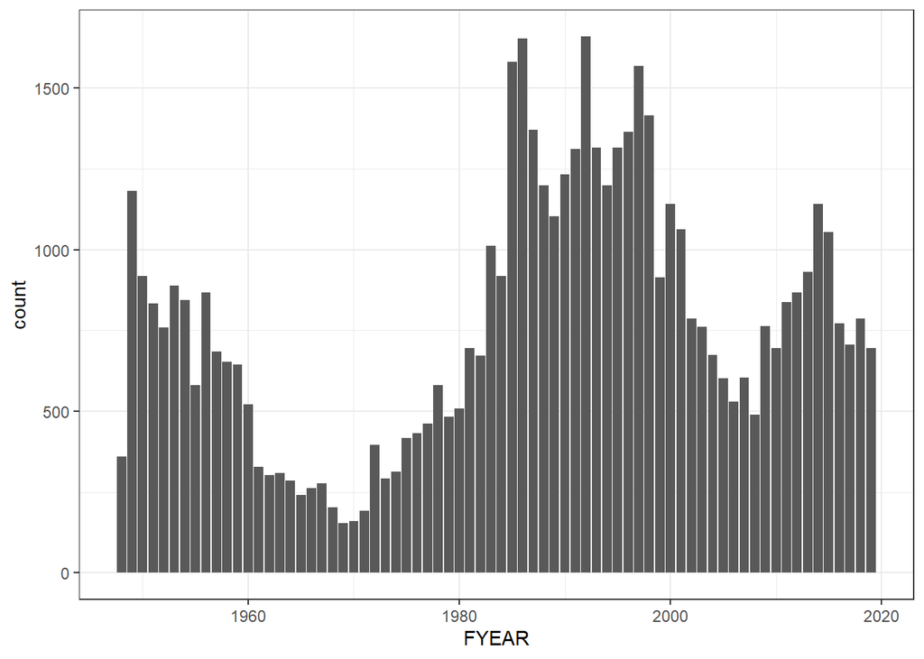

```
##    Min. 1st Qu.  Median    Mean 3rd Qu.    Max.
##    1948    1976    1991    1987    2001    2019
```

Catch by calendar month (monthly mean among calendar years)

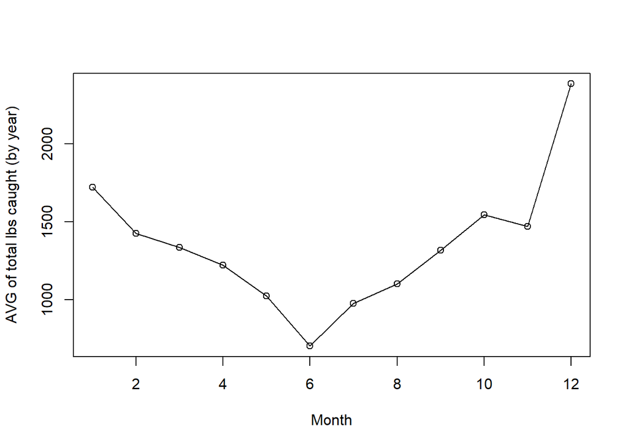

Number of catch records by region (years pooled)

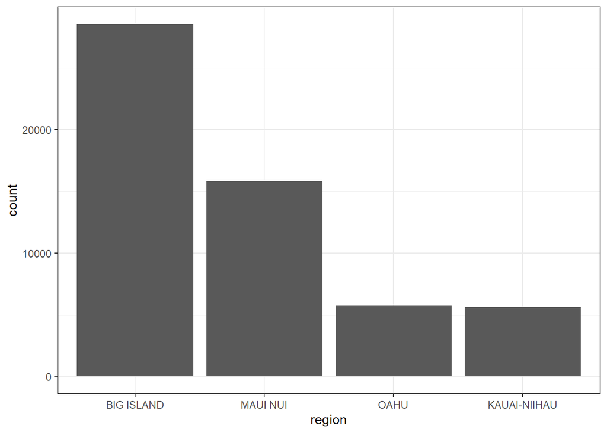

```
##   BIG ISLAND     MAUI NUI         OAHU KAUAI-NIIHAU
##        28538        15837         5761         5620
```

Proportion of kale catch (in lbs) by island region through time

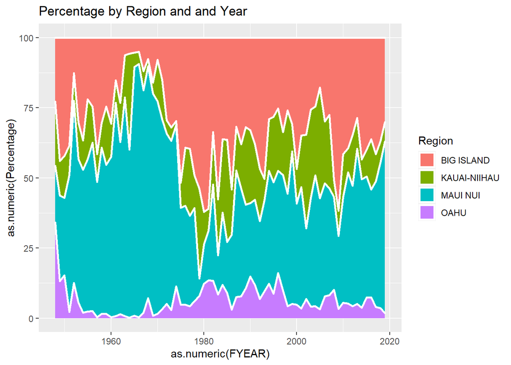

Look at catch by HDAR reporting area

Proportion of records in top 10 and 20 areas, respectively (years pooled).

```
## [1] 0.5554294
```

```
## [1] 0.7436075
```

Top 10 areas ("Group.1")

```
##    Group.1        x
## 61     328 153401.3
## 62     331 140462.6
## 12     122  62619.1
## 58     325  54190.4
## 53     320  48895.7
## 6      105  45554.7
## 11     121  35831.2
## 16     126  34417.4
## 2      101  31644.0
## 15     125  26747.2
```

Maps of catch by HDAR reporting area (total and decade)

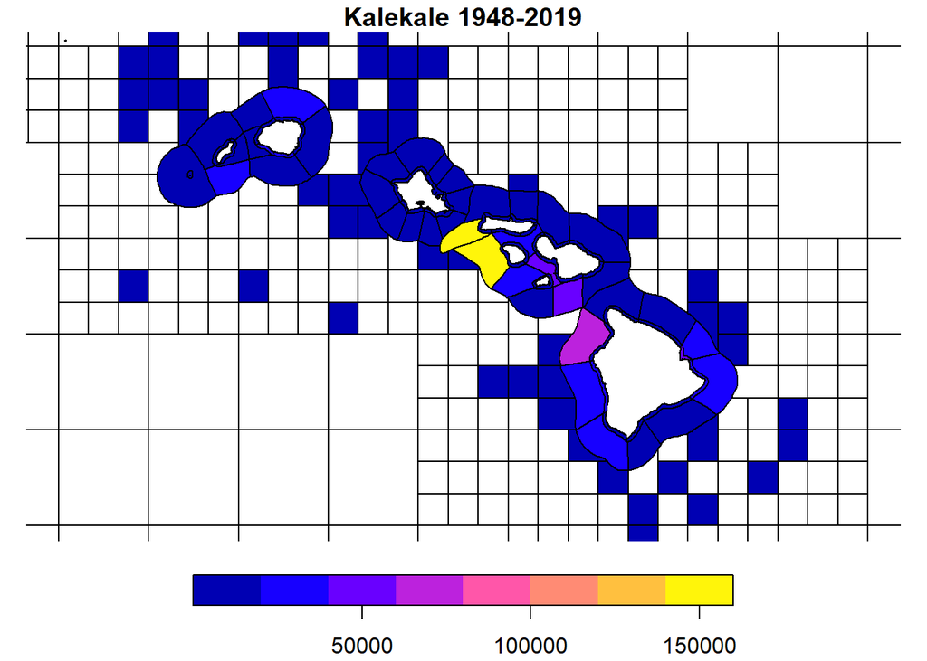

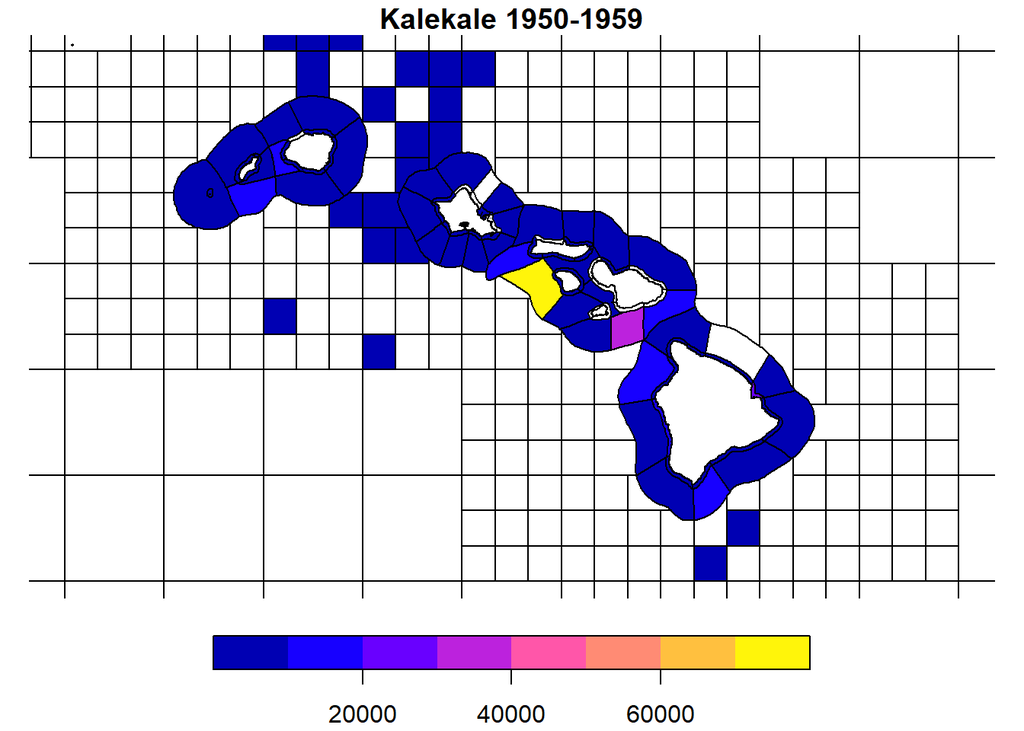

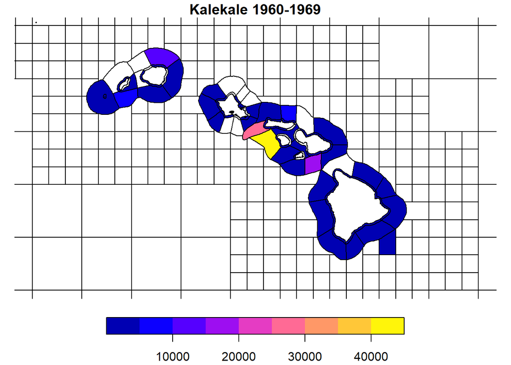

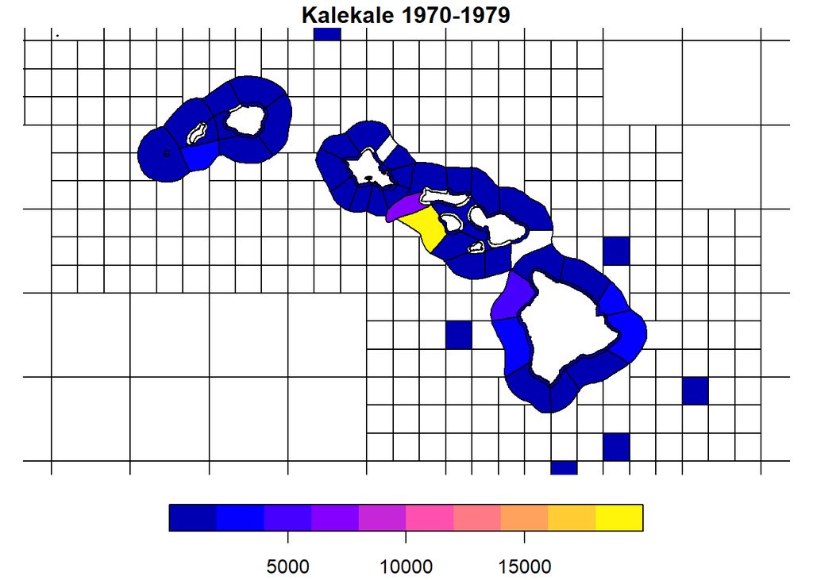

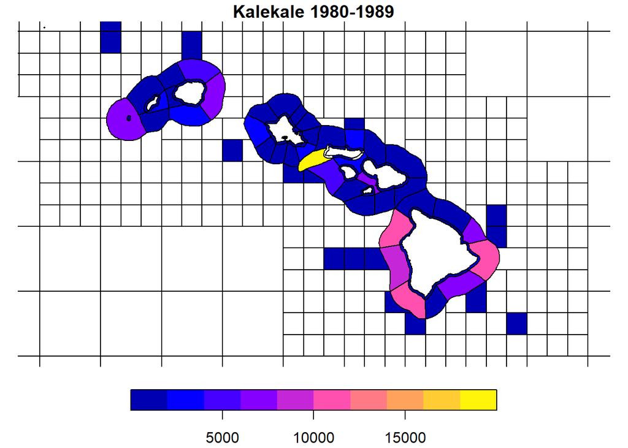

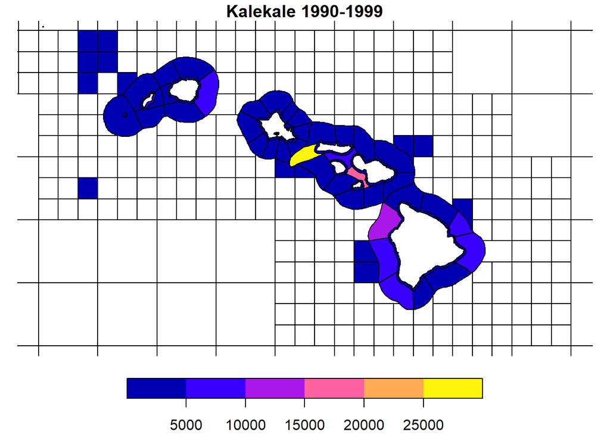

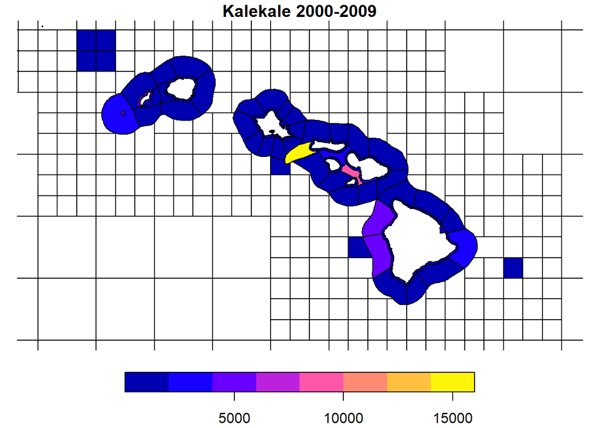

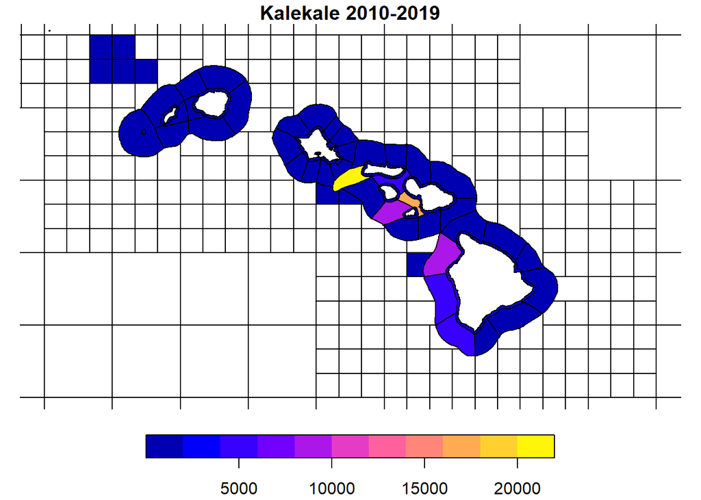

Catch by gear

Proportion of catch (lbs) and records, respectively, on deep-sea handline

```
## [1] 0.9442909
```

```
## [1] 0.921838
```

Catch by gear through time

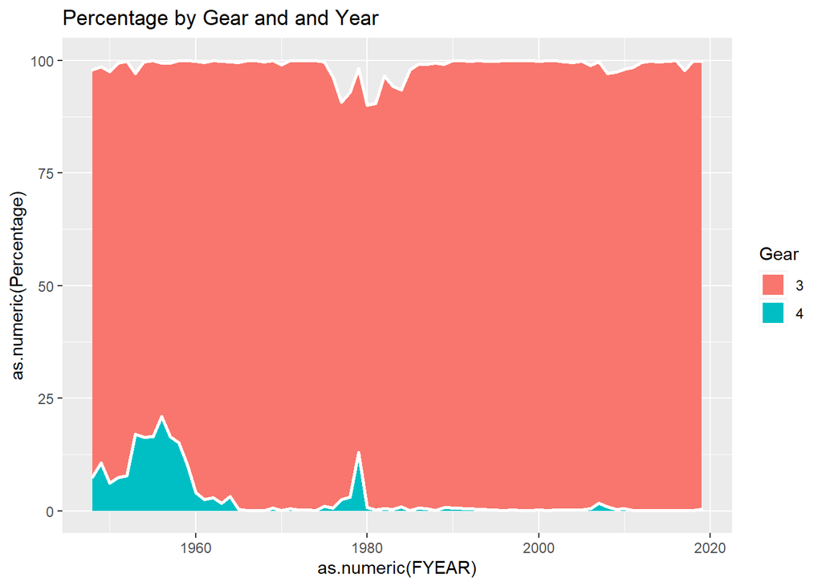

# Lehi

Catch through time

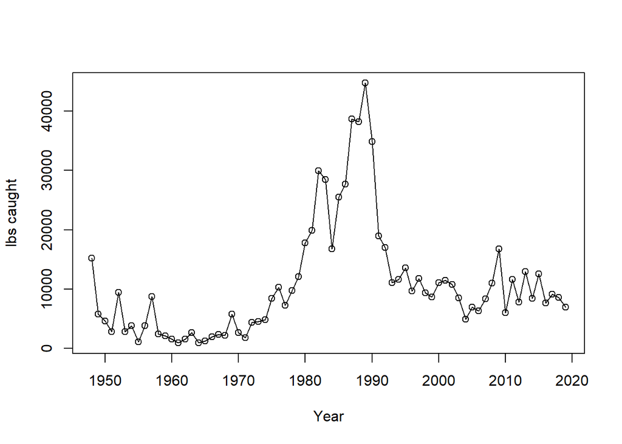

Number of catch records by year

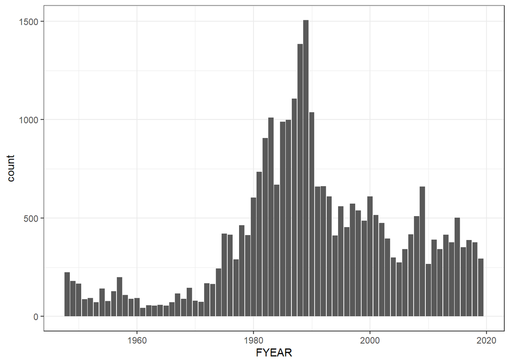

```
##    Min. 1st Qu.  Median    Mean 3rd Qu.    Max.
##    1948    1982    1989    1991    2001    2019
```

Catch by calendar month (monthly mean among calendar years)

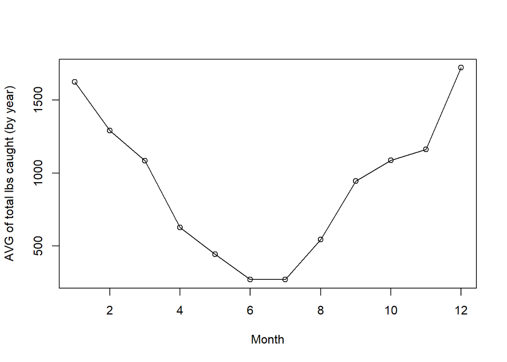

Number of catch records by region (years pooled)

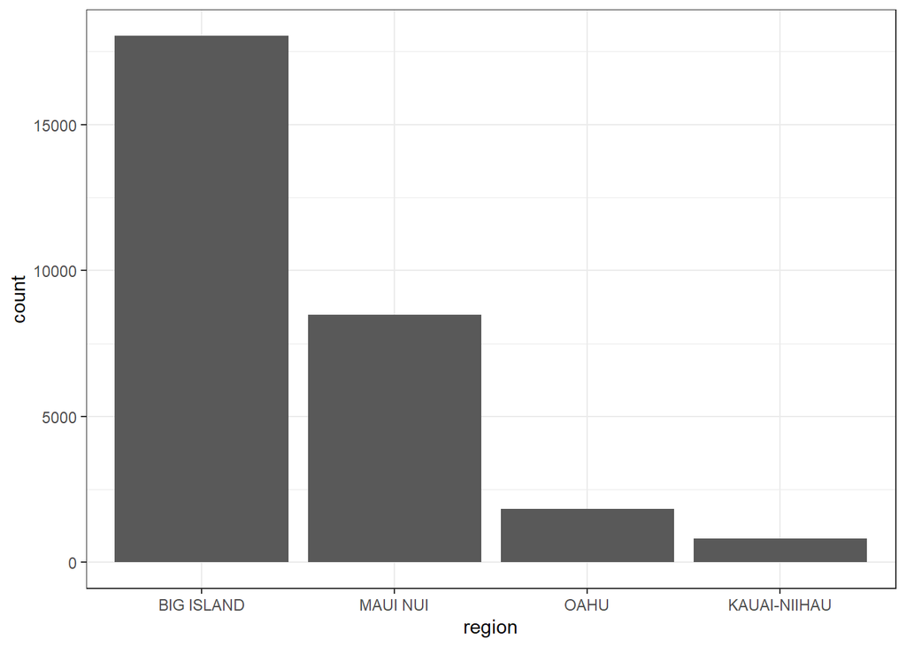

```
##   BIG ISLAND     MAUI NUI         OAHU KAUAI-NIIHAU
##        18037         8490         1836          806
```

Proportion of lehi catch (in lbs) by island region through time

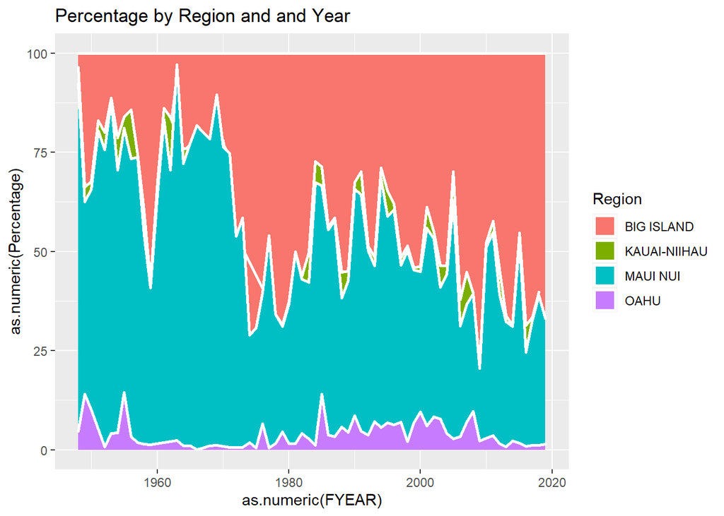

Look at catch by HDAR reporting area

Proportion of records in top 10 and 20 areas, respectively (years pooled).

```
## [1] 0.6996331
```

```
## [1] 0.8502583
```

Top 10 areas ("Group.1")

```
##    Group.1         x
## 49     320 197261.20
## 12     122  89576.90
## 11     121  57782.00
## 56     327  35706.06
## 58     331  32860.00
## 16     126  27009.50
## 17     127  25982.10
## 2      101  25760.80
## 10     120  25660.40
## 18     128  23522.29
```

Maps of catch by HDAR reporting area (total and decade)

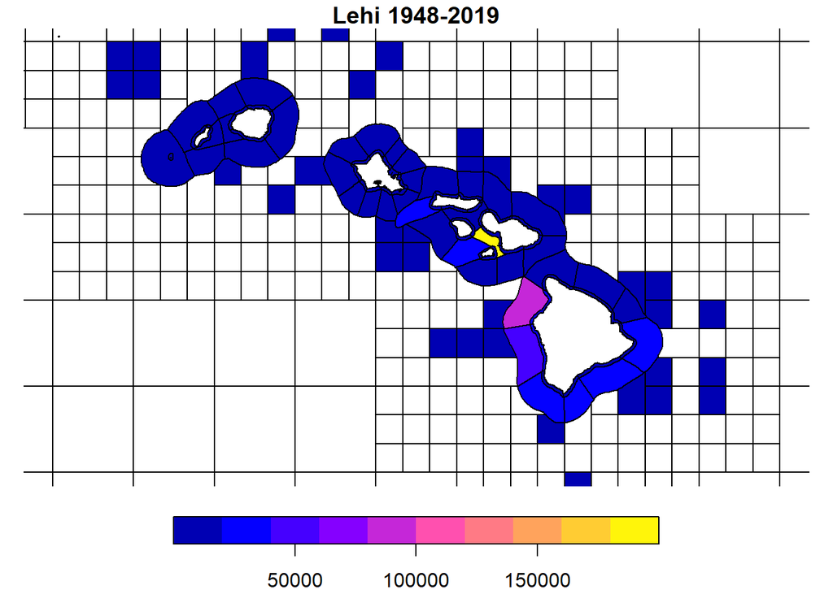

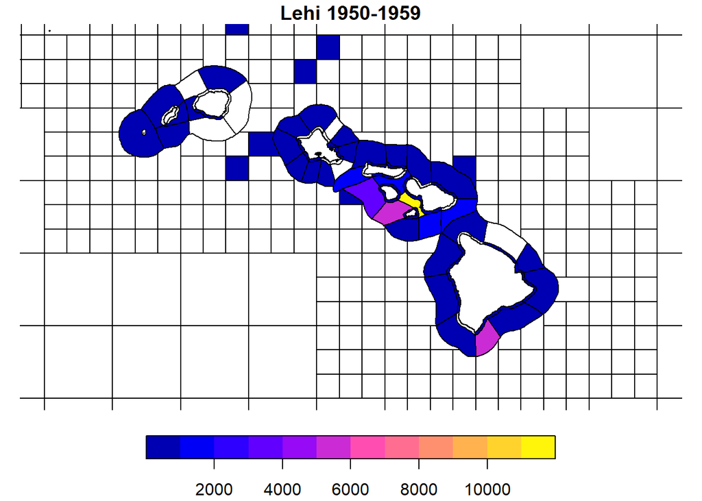

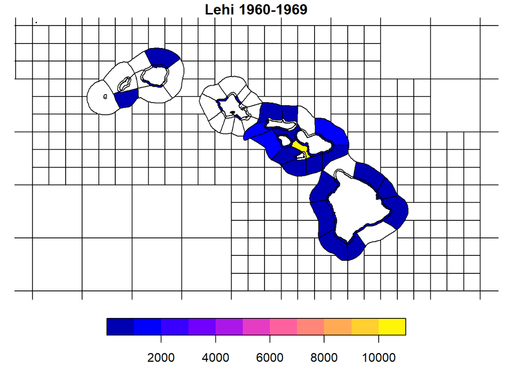

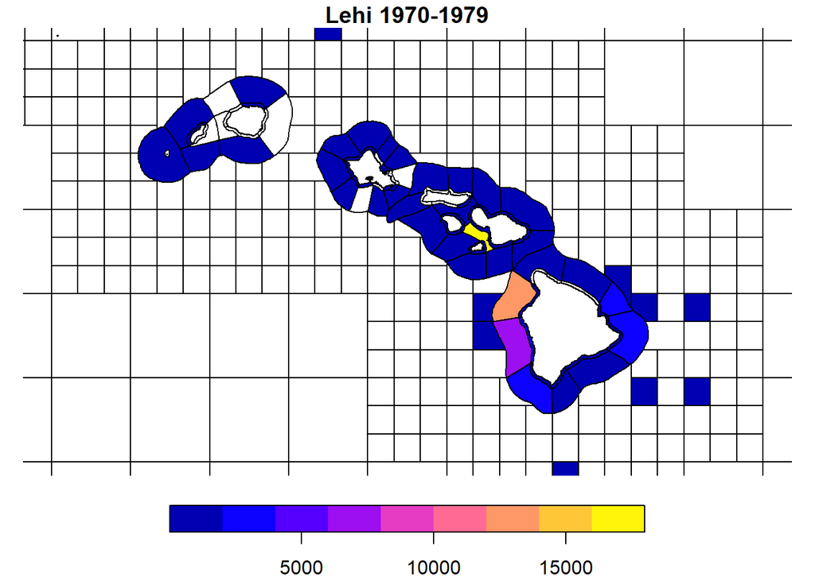

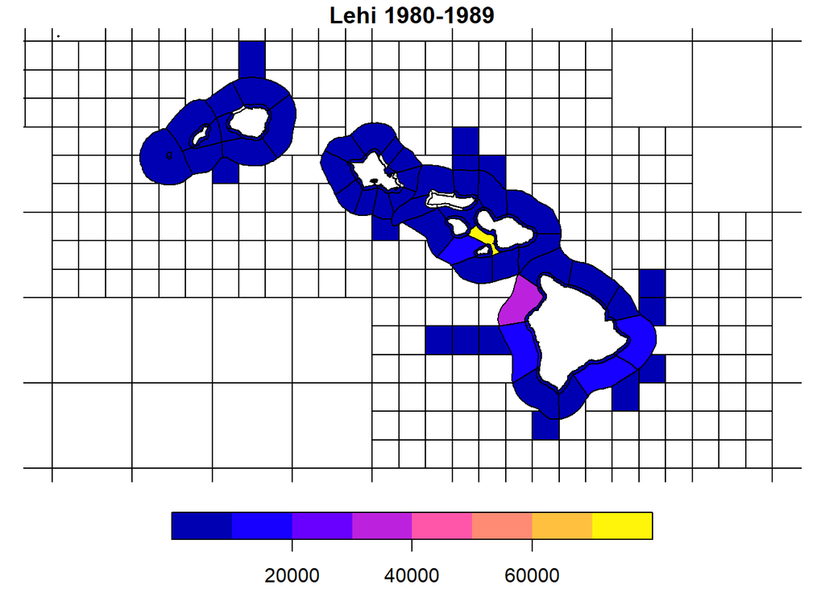

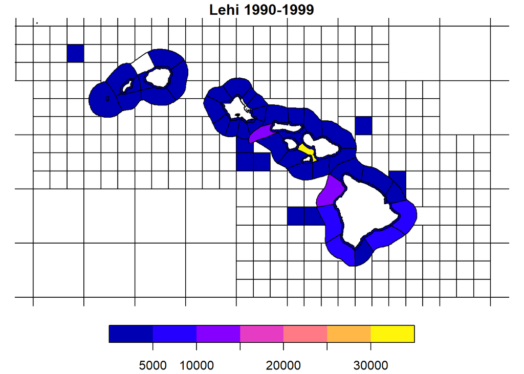

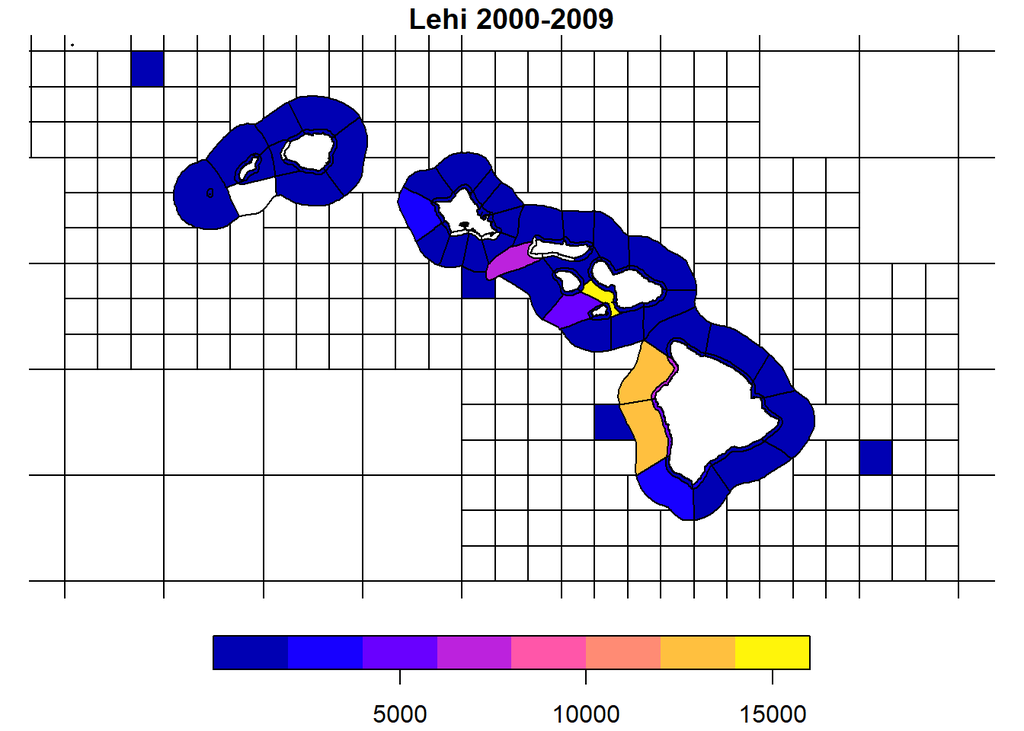

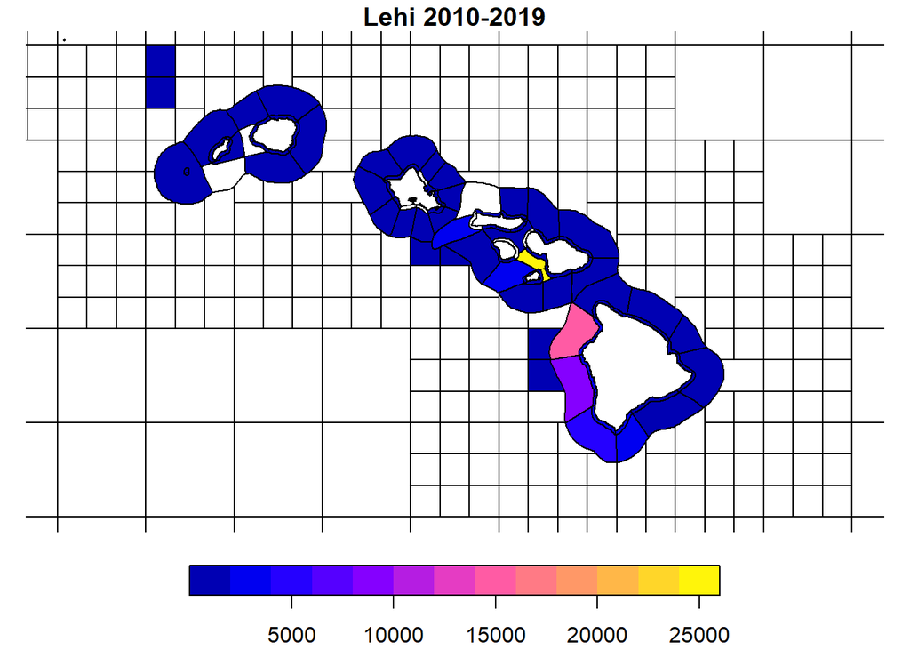

Catch by gear

Proportion of catch (lbs) and records, respectively, on deep-sea handline

[output not shown]

[output not shown]

Catch by gear through time

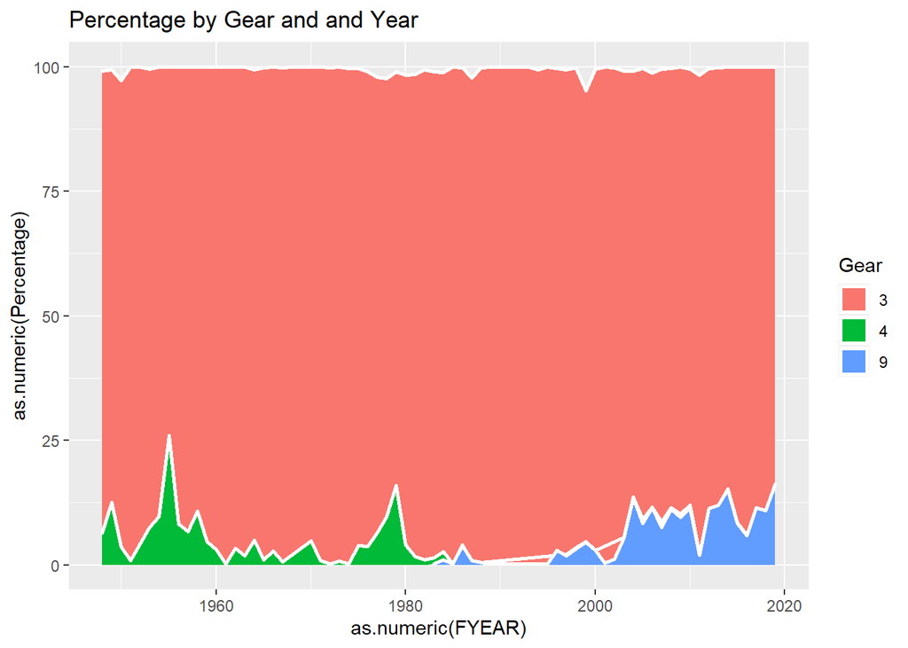